# ScHiCcompare Vignette

My Nguyen and Mikhail Dozmorov

Department of Biostatistics, Virginia Commonwealth University, Richmond, VA

October 7, 2024

#### Package

ScHiCcompare 0.0.0.9000

# 1 Introduction

`ScHiCcompare` is package of functions designed for the imputation, joint normalization, and detection of differential chromatin interactions between two groups of single-cell Hi-C datasets (scHi-C). It works with processed Hi-C data, specifically chromosome-specific chromatin interaction matrices, and accepts five-column tab-separated text files in a sparse matrix format.

What sets `ScHiCcompare` apart from other tools is its focus on processed chromatin interaction matrices rather than raw sequencing data. The package provides two key functionalities:

- Imputation of single-cell Hi-C data
- Differential analysis to identify differences in chromatin interactions between groups.

# 2 Implement

## 2.1 Getting Start

### 2.1.1 Installation

```r
if (!requireNamespace("BiocManager", quietly=TRUE))
   install.packages("BiocManager")

BiocManager::install("ScHiCcompare")

# For the latest version install from GitHub
# devtools::install_github("dozmorovlab/ScHiCcompare")
```

```r
library(scHiCcompare)
library(tidyr)
library(ggplot2)
library(gridExtra)
library(lattice)
```

### 2.1.2 Input schi-c data

You will need processed Hi-C data in the form of sparse upper triangular matrices to use ScHiCcompare with 5 columns (chr1, start1, chr2, start2, IF). ScHi-C data has different formats that are available from several sources, and two examples for downloading and extracting data are listed below.

If you have full Hi-C contact matrices, you convert them to sparse upper triangular format using the `full2sparse()` function of `HiCcomapre` packge, then reformat the column to achieve the requirement input format.

#### 2.1.2.1 Extracting data from .hic files

If you obtain data in the .hic format you will need to first extract the matrices that you wish to compare.

1. Download the straw software from https://github.com/theaidenlab/straw/wiki and install it.
2. Use straw to extract a Hi-C sparse upper triangular matrix. An example is below:

To extract a file scHiC.hic the raw matrix corresponding to chromosome 22 at the 500kb resolution we would use the following command within the terminal

`./straw NONE scHiC.hic 22 22 BP 500000 > scHiC.500kb.txt`

This will extract the matrix from the `.hic` file and save it to the `scHiC.500kb.txt` text file, in the sparse upper triangular matrix format. See more examples on how to use `straw` at https://github.com/theaidenlab/straw/wiki/CPP#running. Straw requires several inputs for the extraction of data from a `.hic` file.

`<NONE/VC/VC_SQRT/KR> <hicFile(s)> <chr1>[:x1:x2] <chr2>[:y1:y2] <BP/FRAG> <binsize>`

From here we can import the matrix into R as you would normally for any tab-delimited file.

3. Import the data into R `data <- read.table('scHiC.500kb.txt', header=FALSE)`
4. Repeat these steps for all scHi-C dataset of 2 groups that you wish to compare.

#### 2.1.2.2 Extracting data from .cool files

To use data in the .cool format, there are multiple ways to read these files (eg., by `cooler` on terminal, by `read_file()` function of `ScHiCcompare` package, etc). We are showing 2 examples of reading .cool files below:

- Tools in R:

  The files can be read directly into R by `read_file()` function of `ScHiCcompare`, or `cooler2bedpe()` function of `HiCcompare`.

  The `read_file` and `cooler2bedpe` functions will return a list object in the format of BEDPE, containing two elements: “cis” - Contains the intra-chromosomal contact matrices, one per chromosome; “trans” - Contains the inter-chromosomal contact matrix.

  Thw example of a scHiC.cool file is imported by `read_file()` function is below. You can read more detail of argument in structure see more in Input material section.

  `library(ScHiCcompare)` `cool.file <- read_files("path/to/scHiC.cool", cell_type = "NSN", position.dataset = 1, type = "cool")`
- Tools in Terminal of Mac/Linus or Command Prompt of Window

  The `cooler` software is one of software on Terminal of Mac/Linus or Command Prompt of Window that reads .cool file http://cooler.readthedocs.io/en/latest/index.html. The cooler index ftp://cooler.csail.mit.edu/coolers contains Hi-C data for `hg19` and `mm9` from many different sources. To read these file and transfer to R, you can follow these steps:
  1. Download and install `cooler` from http://cooler.readthedocs.io/en/latest/index.html
  2. Download a `.cool` file from the cooler index ftp://cooler.csail.mit.edu/coolers. 3.To extract the contact matrix we use the following commands in the terminal (scHiC.cool is an example .cool file):  
     `cooler dump -- scHiC.cool > scHiC.txt`
  3. Read in the text file as you would any tab-delimited file in R  
     dataset <- read.table(“scHiC.txt”, header = FALSE)`
  4. Repeat step 1 - 4 for single cell data.
  5. Transfer these contact matrices of each single cell files into R by using `cooler2sparse()` of `HiCcomapre`:

  `sparse <- cooler2sparse(hesc1000kb)`

## 2.2 ScHiC table

### 2.2.1 Overview

ScHiC table is an object gathering all scHi-C data of a group (a cell type or a condition). This object is usuable for following analysis steps, `Pooling_RF_impute` and `pseudo_bulkHic` functions.

To input for the `scHiC_table`, each single cell Hi-C data need to be processed as a sparse matrix format, which store pair-wise interaction frequencies of loci pairs. Since the full matrix of chromatin interactions is symmetric, only the upper triangular portion, including the diagonal and excluding any 0, is stored as sparse matrix format. The required sparse matrix format of each single cell Hi-C is:

- “chr” - a chromosome of first region
- “start1” - a start coordinate (in bp) of the first region
- “start2” - a start coordinate (in bp) of the second region
- “IF” - the interaction frequency between 2 two regions (IFs)

```r
data(MG_1)
MG_sparse <- MG_1[ ,c(1,2,4,5)]
names(MG_sparse) <- c('chr' , 'start1', 'start2', 'IF')
```

| chr | start1 | start2 | IF |
| --- | --- | --- | --- |
| chr1 | 0 | 1000000 | 13 |
| chr1 | 1000000 | 1000000 | 397 |
| chr1 | 1000000 | 2000000 | 5 |
| chr1 | 2000000 | 2000000 | 433 |
| chr1 | 1000000 | 3000000 | 2 |
| chr1 | 2000000 | 3000000 | 22 |

### 2.2.2 How to create scHiC table

#### 2.2.2.1 Input material

`scHiC_table()` function can receive list of single cell Hi-C datasets in sparse matrix format described as above structure. You can input the scHi-C data of singles cells as above describe ( see more Input schi-c data ), then modify them to sparse format, and gather them in `list()` object. If your datasets have format of ‘txt’ (sparse format) or ‘cool’, you can read and transform scHi-C datasets of a conditions to sparse format by using `read_files()` function to output the `list() object.

`read_files(file.path, cell, position.dataset, type, txt.sparse.heads.position, out)`

- `file.path` - The directory path where the scHiC files are stored.
- `cell` - Cell type name (e.g., ‘MG’, etc).
- `position.dataset` - File positions that you want to read from the directory.
- `type` - The file type, either ‘txt’ or ‘cool’.
- `txt.sparse.heads.position` - Specified head postions (chr, start1, start2, IF) in ‘txt’ file.
- `out`- Output format with options ‘sparse’ and ‘original’. To prepare for `scHiC_table()`, you should select ‘sparse’.

The `read_files()` function output a list of scHiC data in sparse format for `out` = ‘sparse’, where each element corresponds to a dataset from the selected files.

```r
### Load data folder example saved in current working directory
load_example_MGfolder()
MGs.list <- read_files(file.path = "MGs_example", cell = "MG", position.dataset = c(1, 2, 3), type = "txt", txt.sparse.heads.position = c(1,2,4,5))
```

#### 2.2.2.2 scHiC_table function

After obtaining the list of single cell Hi-C dataset in sparse matrix format, you can use the list to transform into scHic table by `scHiC_table` function with the chosen chromosome. You can repeat these steps to generate scHiC tables of 2 conditions that are desired to be compared.

`scHiC_table(file.list, cell.type, position.dataset, select.chromosome)`

- `file.list` - The list object where elements are processed scHi-C data file.
- `cell.type` - The cell type used in the analysis (e.g., ‘NSN’, ‘SN’).
- `position.dataset` - A vector of indices specifying the file positions to read from the directory.
- `select.chromosome` - The chromosome name to be studied (e.g., ‘chr1’ or ‘chrX’).

The `scHiC_table()` function will output a table where its columns includes genomic loci (cell, chromosome, start1, end1) and interaction frequencies (IF) of each single cell.

```r
### Input single cell hi-c in sparse format (.txt) from a path
scHiC.table_MG = scHiC_table(file.list  = MGs.list,
                             cell.type = 'MG',
                             position.dataset =  1:3,
                             select.chromosome = 'chr22')
```

[output not shown]

[output cut: 40 more lines]

## 2.3 Imputation

### 2.3.1 Overview

Single cell Hi-C data tends to be more sparsed due to the limitation of material at each single cell and technical challenges, and it is worse at missing more information at higher resolution. Imputation is designed to mitigate the sparsity chalenges by filling in missing data at the single-cell level.

The imputation process first segment data into its genomic distance (region2 - region1), then gather scHi-C distance data into pool bands based on its shared similar genomic distance effect (or similar mean of IFs at each of these distance data). There are 2 pooling style: progressive pooling and Fibonacci pooling. Progressive pooling pools of distances are consecutively combined to form larger sets, while Fibonacci pooling uses a Fibonacci sequence to combine distances.

Random forest imputation is applied on each pool band. During the imputation process, the function imputes all missing values (NAs) within each pool within the main distance range. For distances outside this main focus range, if any pool contains more than `missPerc.theshold` missing values, it triggers an alternative imputation method, filling in missing values based on the mean for distances.

### 2.3.2 How to impute scHi-C data

#### 2.3.2.1 Input material

To use `Pooling_RF_impute()`, we need scHiC table object created in previous section, which gather all single cells’ Hi- C data of a condition ( see more How to create scHiC table ).

#### 2.3.2.2 Pooling_RF_impute function

After obtaining the scHiC table of all single cell Hi-C dataset in sparse matrix format, you can impute these cells interaction frequencies by `Pooling_RF_impute` function with the chosen pooling style. Note that these single cells should belong to the same cell type or condition for each chromosome. You can repeat these steps to impute scHi-C data of 2 conditions that you wish to compare.

`Pooling_RF_impute(scHiC.table, n.imputation,main.Distances, pool.style, ...)`

- `scHiC.table` - the scHic table oject across single cells created by the `scHiC_table()`.
- `n.imputation` - Number of multiple imputations you want, from which the final imputed interaction frequencies (IFs) will be aggregated as a mean. The default is 5 imputations.
- `main.Distances` - The genomic distance range (in bp) you want to focus on for full random forest imputation (e.g., 1:1000000). You can select ‘full’ for all scHiC data imputed. The default is from 1 to 10,000,000 bp.
- `pool.style` - The pooling technique to be used. Options are ‘progressive’ or ‘fibonacci’. The default is ‘progressive’. For high-resolution data, ‘progressive’ may fail due to extreme sparsity, so it’s recommended to switch to ‘fibonacci’, though it may take longer to compute.
- - For other detail, you can look up `?Pooling_RF_impute()`

The function `Pooling_RF_impute()` outputs imputed interactions frequency of each single cell in form of scHiC table, where each column is the imputed interaction frequency values for each single cells.

```r
## Imputation
imp.cc.table.1 <- Pooling_RF_impute(scHiC.table = scHiC.table_ODC, n.imputation = 10,
                              main.Distances = 1:10000000, pool.style = 'progressive')
```

|  | region1 | region2 | cell | chr | IF_1 | IF_2 | IF_3 | IF_4 | IF_5 | IF_6 | IF_7 | IF_8 | IF_9 | IF_10 | IF_11 | IF_12 | IF_13 | IF_14 | IF_15 | IF_16 | IF_17 | IF_18 | IF_19 | IF_20 | IF_21 | IF_22 | IF_23 | IF_24 | IF_25 | … |
| --- | --- | --- | --- | --- | --- | --- | --- | --- | --- | --- | --- | --- | --- | --- | --- | --- | --- | --- | --- | --- | --- | --- | --- | --- | --- | --- | --- | --- | --- | --- |
| 1 | 16000000 | 16000000 | ODC | chr22 | 33 | 34 | 61 | 16 | 52 | 61 | 41 | 30 | 26 | 48 | 25 | 39 | 32 | 75 | 48 | 49 | 62 | 46 | 51 | 61 | 59 | 33 | 31 | 54 | 43 | … |
| 2 | 17000000 | 17000000 | ODC | chr22 | 297 | 264 | 427 | 158 | 438 | 425 | 331 | 266 | 271 | 388 | 266 | 345 | 322 | 559 | 389 | 425 | 489 | 410 | 325 | 479 | 360 | 268 | 206 | 307 | 288 | … |
| 3 | 18000000 | 18000000 | ODC | chr22 | 252 | 261 | 430 | 153 | 399 | 385 | 349 | 239 | 272 | 369 | 243 | 325 | 300 | 556 | 351 | 436 | 449 | 363 | 369 | 448 | 317 | 291 | 180 | 274 | 293 | … |
| 4 | 19000000 | 19000000 | ODC | chr22 | 412 | 385 | 586 | 236 | 666 | 631 | 529 | 371 | 373 | 573 | 403 | 511 | 464 | 749 | 505 | 619 | 654 | 532 | 483 | 652 | 526 | 418 | 258 | 415 | 442 | … |
| 5 | 20000000 | 20000000 | ODC | chr22 | 260 | 239 | 370 | 134 | 373 | 341 | 333 | 230 | 228 | 342 | 253 | 281 | 253 | 452 | 327 | 385 | 351 | 328 | 278 | 431 | 262 | 230 | 164 | 234 | 258 | … |
| 6 | 21000000 | 21000000 | ODC | chr22 | 212 | 182 | 291 | 105 | 301 | 290 | 257 | 199 | 193 | 278 | 171 | 255 | 221 | 414 | 242 | 284 | 358 | 299 | 246 | 374 | 239 | 224 | 147 | 209 | 247 | … |
| 7 | 22000000 | 22000000 | ODC | chr22 | 357 | 355 | 479 | 190 | 492 | 506 | 424 | 302 | 296 | 493 | 312 | 356 | 391 | 621 | 405 | 502 | 516 | 481 | 391 | 602 | 430 | 339 | 249 | 347 | 370 | … |
| 8 | 23000000 | 23000000 | ODC | chr22 | 420 | 364 | 530 | 202 | 561 | 592 | 545 | 306 | 369 | 540 | 350 | 458 | 446 | 700 | 481 | 573 | 601 | 540 | 424 | 662 | 477 | 355 | 283 | 495 | 418 | … |
| 9 | 24000000 | 24000000 | ODC | chr22 | 357 | 385 | 504 | 224 | 547 | 543 | 478 | 314 | 323 | 492 | 303 | 436 | 391 | 671 | 409 | 512 | 556 | 424 | 391 | 579 | 388 | 347 | 232 | 362 | 410 | … |
| 10 | 25000000 | 25000000 | ODC | chr22 | 311 | 277 | 450 | 178 | 415 | 448 | 443 | 267 | 311 | 410 | 255 | 404 | 353 | 639 | 392 | 486 | 454 | 409 | 396 | 548 | 405 | 286 | 207 | 379 | 337 | … |

[output cut: 40 more lines]

## 2.4 scHiC - Pseudo bulk data

### 2.4.1 Overview

One intermediate step in the `ScHiCcompare` workflow is transforming data into pseudo-bulk matrices. The output of speudo bulk matrices of two comparing groups is usable foe next step of the implement of normalization by `HiC_loess()` of `HiCcompare` package and `scHiC_bulk_compare()` of our implement.

After the imputation of contacts within pooling groups, the data is reorganized into single-cell matrices for each cell type or condition. The imputed single-cell matrices within each group are summed to generate two pseudo-bulk matrices, one for each cell type or condition. By assuming that the interaction frequency between two loci in a single cell follows a similar distribution across all scHi-C matrices for a same cell type or condition, summing these interactions allows us to gather the maximum amount of information about each condition.

### 2.4.2 How to create scHiC - Pseudo bulk

#### 2.4.2.1 Input material

To use `Pooling_RF_impute()`, we need scHiC table object created in previous section, which gather all single cells’ Hi- C data of a condition ( see more How to create scHiC table ). You can run this step with imputed scHi-C table (output of imputation Pooling_RF_impute function ) or without imputed scHi-C table (output of scHiC_table function).

#### 2.4.2.2 pseudo_bulkHic function

With the input of a scHiC table, you can create speudo bulk matrix of a cell type or condition by `scHiC.table` pseudo_bulkHic. You can repeat these steps to create speudo bulk matrices of 2 conditions that you wish to compare.

`pseudo_bulkHic(scHiC.table, out)`

- `scHiC.table` - the scHic table oject across single cells created by the `scHiC_table()` or output of the `Pooling_RF_impute()`
- `out` - the output format of pseudo bulk with option of ‘sparse’ or ‘full’ matrix.

The function outputs a data frame representing the pseudo-bulk Hi-C data. If `out` is ‘sparse’, the output is in the format of a sparse upper triangular Hi-C matrix. If `out` is ‘full’, the output is in the format of a full speudo bulk Hi-C matrix.

```r
## Bulk matrix in sparse format
bulk.imp.sparse.1 = na.omit(pseudo_bulkHic(scHiC.table = imp.cc.table.1,
                                                     out = 'sparse'))
```

## 2.5 Differential Analysis

### 2.5.1 Overview

The differential analysis aims to detect differential chromatin interactions between single-cell Hi-C data from two cell types or conditions. The workflow involves clustering normalized log fold changes of interaction frequencies at each genomic distance between two cell types or conditions into difference and non-difference clusters.

The non-difference cluster’s log fold changes is assumed to have normal distribution centered around 0, identified through a Gaussian Mixture Model (GMM) cluster. The difference group consists of log fold changes belonging to other distributions clusters that deviate from the non-difference group’s normal distribution. To improve the precision of difference group clustering, a control fold change threshold `fprControl.logfc` is applied, excluding bins with low log fold changesto focus on meaningful differences.

In cases where the size of the differences is not large enough to form distinct distributions, these differences are likely outliers of the normal distribution, which are identified by the differential analysis of `HiCcompare`.

### 2.5.2 How to apply differential analysis

#### 2.5.2.1 Input material

The function `hic_loess` of `HiCcompare` package need input of `hic.table` object, which is generated from pair of sparse upper triangular Hi-C matrices, can also be created using `create.hic.table()` function.

`create.hic.table(sparse.mat1, sparse.mat2, chr, scale, ...)`

- `sparse.mat1` - The input for the first sparse upper triangular Hi-C matrix. This can be the sparse matrix format of the pseudo-bulk scHi-C data from a specific cell type group, created using the `pseudo_bulkHic()` function (see more pseudo_bulkHic function).
- `sparse.mat2` - The input for the second sparse upper triangular Hi-C matrix. Similarly, this can be the sparse matrix format of the pseudo-bulk scHi-C data from another cell type group, also created using the `pseudo_bulkHic()` function (see more pseudo_bulkHic function).
- `chr` - The chromosome name corresponding to the matrices being entered, e.g., ‘chr1’ or ‘chrX’.
- `scale` - Logical. If TRUE, the interaction frequencies (IFs) of the second sparse matrix will be adjusted as follows: IF2_scaled = $IF2 / (sum(IF2) / sum(IF1))$. In our analysis, we set `scale` to FALSE.
- For other detail, you can look up `?create.hic.table()`.

The function return `hic.table` object that can be used to normalize in `hic_loess`.

```r
data("scHiC.table_MG")
data("scHiC.table_ODC")

library(HiCcompare)
## Create Pseudo Bulk matrix in sparse format
bulk.sparse.1 = na.omit(pseudo_bulkHic(scHiC.table = scHiC.table_MG,
                                           out = 'sparse'))
bulk.sparse.2 = na.omit(pseudo_bulkHic(scHiC.table = scHiC.table_ODC,
                                           out = 'sparse'))
bulk.hic.table = create.hic.table(bulk.sparse.1, bulk.sparse.2,
                                    chr ='chr22', scale = F)
```

```r
DT::datatable(head(bulk.hic.table, 50), options = list(scrollX = TRUE), width = 700)
```

|  | chr1 | start1 | end1 | chr2 | start2 | end2 | IF1 | IF2 | D | M |
| --- | --- | --- | --- | --- | --- | --- | --- | --- | --- | --- |
| 1 | chr22 | 16000000 | 17000000 | chr22 | 16000000 | 17000000 | 128 | 2195 | 0 | 4.100005224422721 |
| 2 | chr22 | 17000000 | 18000000 | chr22 | 17000000 | 18000000 | 988 | 17049 | 0 | 4.109032269187808 |
| 3 | chr22 | 18000000 | 19000000 | chr22 | 18000000 | 19000000 | 943 | 16613 | 0 | 4.138911039695 |
| 4 | chr22 | 19000000 | 20000000 | chr22 | 19000000 | 20000000 | 1383 | 24292 | 0 | 4.134608212699579 |
| 5 | chr22 | 20000000 | 21000000 | chr22 | 20000000 | 21000000 | 869 | 14535 | 0 | 4.0640310842092 |
| 6 | chr22 | 21000000 | 22000000 | chr22 | 21000000 | 22000000 | 685 | 12205 | 0 | 4.155224496820627 |
| 7 | chr22 | 22000000 | 23000000 | chr22 | 22000000 | 23000000 | 1191 | 20321 | 0 | 4.092726080820152 |
| 8 | chr22 | 23000000 | 24000000 | chr22 | 23000000 | 24000000 | 1314 | 22929 | 0 | 4.125136255414885 |
| 9 | chr22 | 24000000 | 25000000 | chr22 | 24000000 | 25000000 | 1246 | 20753 | 0 | 4.057943930323766 |
| 10 | chr22 | 25000000 | 26000000 | chr22 | 25000000 | 26000000 | 1038 | 18774 | 0 | 4.176857715604197 |

[output cut: 40 more lines]

- `hic.table` - `hic.table` object that is created from `create.hic.table` function above
- `Plot` - Logical, if the MD plot showing before/after loess normalization be output
- `Plot.smooth` - Logical, defaults to TRUE indicating the MD plot will be a smooth scatter plot. Set to FALSE for a scatter plot with discrete points.
- For other detail, you can look up `?hic_loess()`

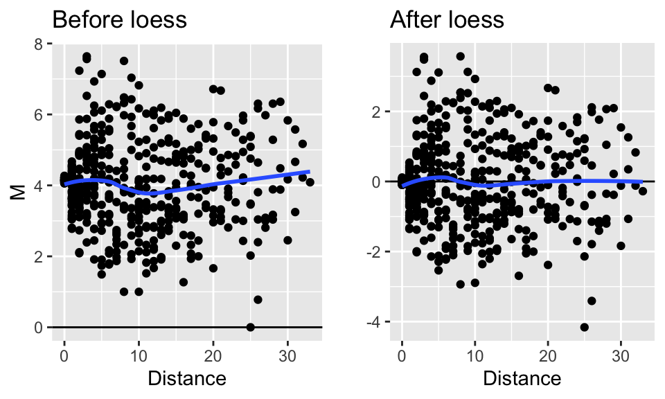

```r
#jointly normalize data for a single chromosome
hic.table_normalize <- hic_loess(hic.table = bulk.hic.table, Plot = T, Plot.smooth = F)
```

#### 2.5.2.2 scHiC_bulk_compare function

After obtaining the `hic.table` object showing the normalization result from speudo bulk matrices of two cell type groups or conditions, we can input it to `scHiC_bulk_compare()` function for further differential analysis.

`scHiC_bulk_compare(norm.hic.table , D.interval, A.min, fprControl.logfc, Plot, ...)`

- `norm.hic.table` - The `hic.table` object of the `hic_loess` function for pair of pseudo bulk matrices.
- `D.interval` - The distance intervals to consider in the analysis, or ‘full’ option indicating the inclusion of all genomic distances in the analysis. The distance should be scaled by dividing by the data resolution, D = (start2 - start1)/resolution (e.g., D = (16,000,000 - 17,000,000)/1,000,000 -> D = 1).
- `A.min` - his parameter represents the quantile cutoff level used to filter low-expression interaction frequency (IF) bins during differential outlier detection in the hic_compare() function. Specifically, log fold change values associated with average expression levels (A, the mean of IF1 and IF2) below the specified A.min quantile are excluded from the analysis. You can specify the quantile level (e.g., 0.1, 0.2) as a numeric value between 0 and 1. You can also use `best_A()` function to identify best A level that maximize the test performance.
- `fprControl.logfc` - The value controlling the false positive rate by setting the threshold for the log fold change of differences. Detected differences should have a value larger than this threshold. Default is 0.8.
- For other detail, you can look up `?scHiC_bulk_compare()`

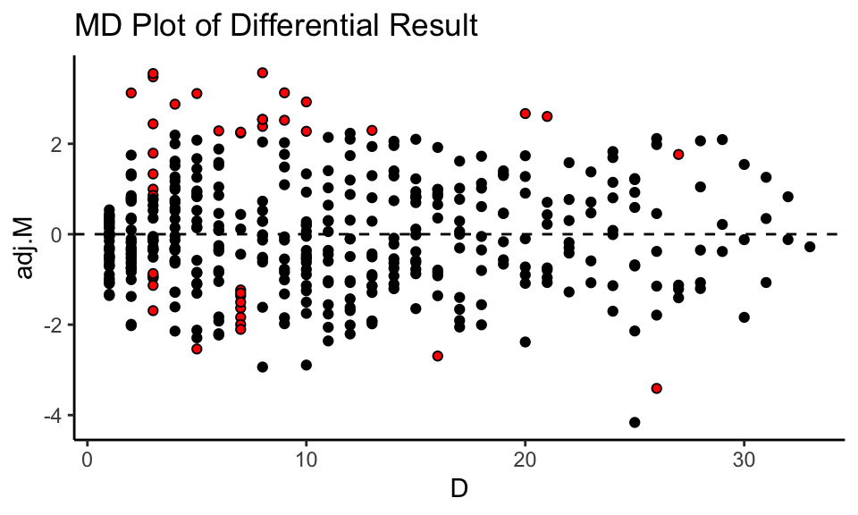

```r
A = best_A(hic.table = hic.table_normalize, numChanges = 20)
## Find differences
hic.table.result <- scHiC_bulk_compare(norm.hic.table = hic.table_normalize, D.interval = 'full', A.min = A,
                                    fprControl.logfc = 0.8, Plot = T)
```

## 2.6 Other functions

There are several other functions included in `ScHiCcompare`.

plot_imputation_heatmap() produces a heatmap visualization for HiC and scHiC matrices. It requires input of sparse matrix format. You can read more detail about it by its help document or see example below Pseudo Bulk.

```
## Matrix dimensions: 250x250
```

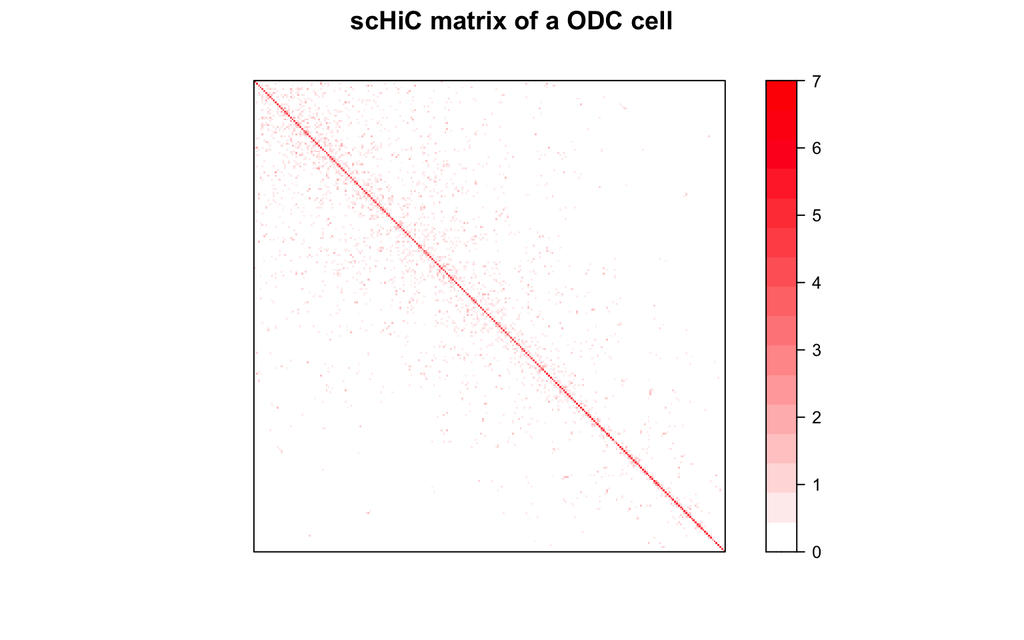

```r
plot.df = ODCs.list[[1]][,-1]
plot_imputation_heatmap(plot.df, main = 'scHiC matrix of a ODC cell')
```

plot_imputed_distance_diagnostic() produces a visualization for imputation diagnostic at each genomic distsnce. It compare the distribution of a given distance data before and after imputation. It requires input of scHiC table of the original and imputed scHiC datasets. You can read more detail about it by its help document or see example below Imputation.

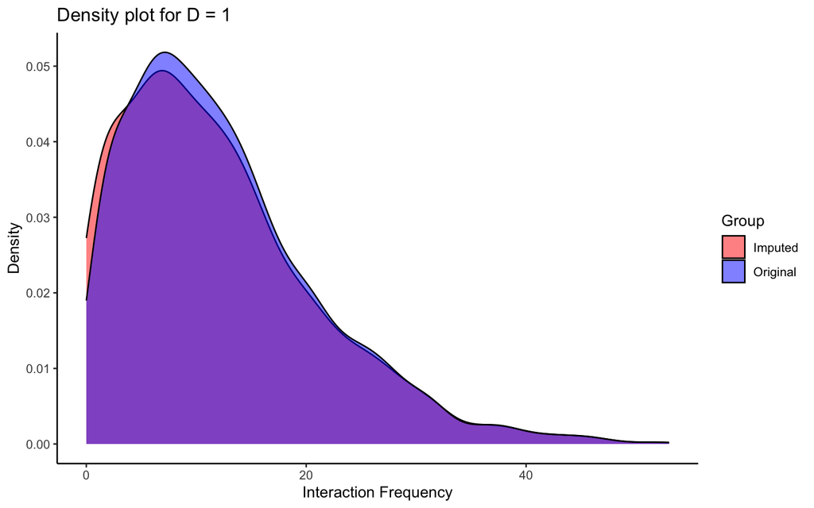

```r
plot_imputed_distance_diagnostic(org_sc_data = imp.cc.table.1, imp_sc_data = scHiC.table_ODC, D = 1)
```

# 3 Example of scHiCompare workflow

#### 3.0.0.1 Create ScHiC table

```r
## Load and create folder for example data
data(ODCs.list)
data(MGs.list)

## Create ScHiC table
scHiC.table_ODC = scHiC_table(file.list = ODCs.list,
                              cell.type = 'ODC',
                              position.dataset =  1:50,
                              select.chromosome = 'chr22')
scHiC.table_MG = scHiC_table(file.list = MGs.list,
                              cell.type = 'MG',
                              position.dataset =  1:50,
                              select.chromosome = 'chr22')
```

#### 3.0.0.2 Imputation

In this example, we focus on imputing at genomic distance from 1 to 10,000,000 (bp) with 10 times multiple imputation. We select to progressive pooling style to create pool bands for random forest imputation.

```r
## Imputation with 'progressive' pooling
imp.cc.table.1 <- Pooling_RF_impute(scHiC.table = scHiC.table_ODC, n.imputation = 10,
                              main.Distances = 1:10000000, pool.style = 'progressive')
```

```
## [1] "Imputing pool band 1"
## [1] "Imputing pool band 2"
## [1] "Imputing pool band 3"
## [1] "Imputing pool band 4"
## [1] "Imputing pool band 5"
## [1] "Imputing pool band 6"
## [1] "Imputing pool band 7"
## [1] "Imputing pool band 8"
## [1] "Imputing pool band 9"
```

```r
imp.cc.table.2 <- Pooling_RF_impute(scHiC.table = scHiC.table_MG, n.imputation = 10,
                              main.Distances = 1:10000000, pool.style = 'progressive')
```

```
## [1] "Imputing pool band 1"
## [1] "Imputing pool band 2"
## [1] "Imputing pool band 3"
## [1] "Imputing pool band 4"
## [1] "Imputing pool band 5"
## [1] "Imputing pool band 6"
## [1] "Imputing pool band 7"
## [1] "Imputing pool band 8"
## [1] "Imputing pool band 9"
```

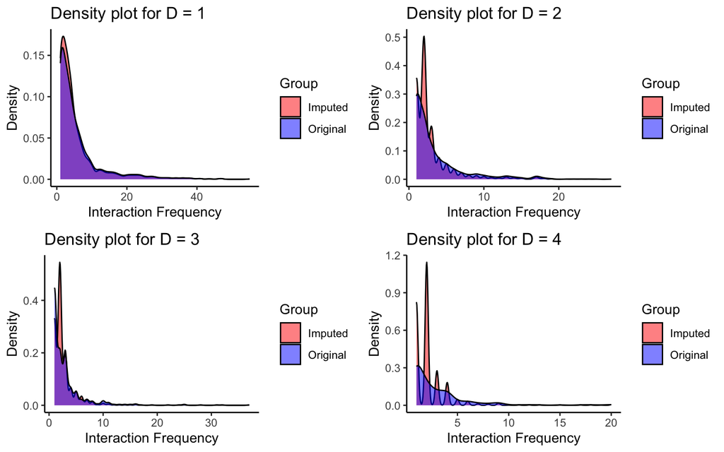

```r
# plot imputed Distance Diagnostic
plot1 = plot_imputed_distance_diagnostic(org_sc_data = scHiC.table_ODC, imp_sc_data = imp.cc.table.1, D = 1)
plot2 = plot_imputed_distance_diagnostic(org_sc_data = scHiC.table_ODC, imp_sc_data = imp.cc.table.1, D = 2)
plot3 = plot_imputed_distance_diagnostic(org_sc_data = scHiC.table_ODC, imp_sc_data = imp.cc.table.1, D = 3)
plot4 =plot_imputed_distance_diagnostic(org_sc_data = scHiC.table_ODC, imp_sc_data = imp.cc.table.1, D = 4)
grid.arrange(plot1, plot2, plot3, plot4, ncol = 2, nrow =2)
```

#### 3.0.0.3 Pseudo Bulk

```r
## Bulk matrix in sparse format
bulk.imp.sparse.1 = na.omit(pseudo_bulkHic(scHiC.table = imp.cc.table.1,
                                           out = 'sparse'))
bulk.imp.sparse.2 = na.omit(pseudo_bulkHic(scHiC.table = imp.cc.table.2,
                                           out = 'sparse'))
```

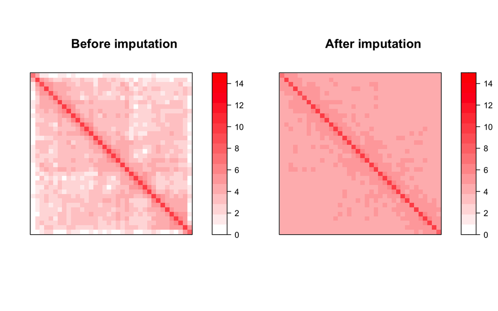

```r
## Pseudo Bulk at main Distain 1:1,000,000

bulk.org.sparse.1 = pseudo_bulkHic(scHiC.table =scHiC.table_ODC, out = 'sparse')

## plot heatmap of speudobulk

plot1 = plot_imputation_heatmap(scHiC.sparse = bulk.org.sparse.1, main = 'Before imputation',  zlim = c(0, 15))
plot2 = plot_imputation_heatmap(scHiC.sparse = bulk.imp.sparse.1, main = 'After imputation',  zlim = c(0, 15))
grid.arrange(plot1, plot2, ncol = 2, name = 'arrange')
```

#### 3.0.0.4 Loess Normalization

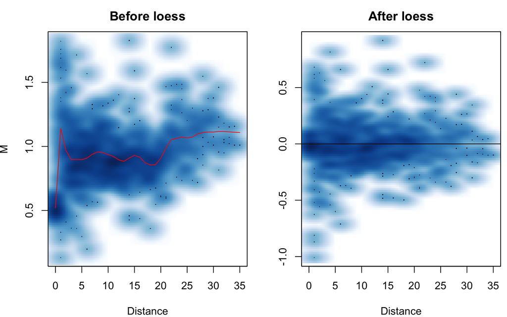

```r
## Jointly normalize data for a single chromosome by Loess HiCcompare
library(HiCcompare)
# create the `hic.table` object
bulk.hic.table <- create.hic.table(bulk.imp.sparse.1, bulk.imp.sparse.2, chr = 'chr22', scale = F)
#jointly normalize data for a single chromosome
hic.table_normalize <- hic_loess(bulk.hic.table, Plot = T, Plot.smooth = T)
```

#### 3.0.0.5 Differential Analysis

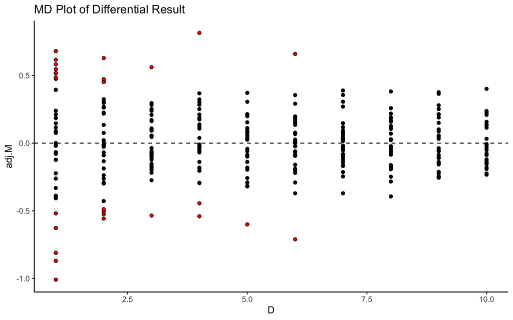

```r
hic.table.result <- scHiC_bulk_compare(norm.hic.table = hic.table_normalize, D.interval = 1:10,
                                    fprControl.logfc = 0.5, Plot = T)
```